# Machine Learning: AllLife Bank Personal Loan Campaign

### Pruned Model Decision Tree Visualization

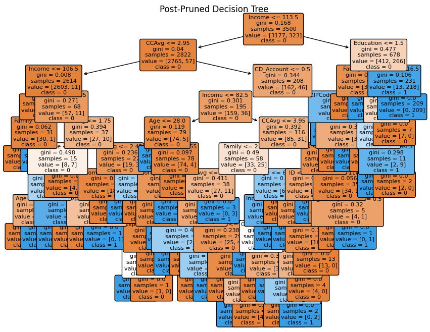

```
IF Income <= 113.5 AND CCAvg <= 2.950000047683716 AND Income <= 106.5 THEN Personal_Loan = 0
IF Income <= 113.5 AND CCAvg <= 2.950000047683716 AND Income > 106.5 AND Education <= 1.5 AND Family <= 3.5 THEN Personal_Loan = 0
IF Income <= 113.5 AND CCAvg <= 2.950000047683716 AND Income > 106.5 AND Education <= 1.5 AND Family > 3.5 THEN Personal_Loan = 1
IF Income <= 113.5 AND CCAvg <= 2.950000047683716 AND Income > 106.5 AND Education > 1.5 AND CCAvg <= 1.75 AND Experience <= 31.5 AND Family <= 1.5 AND Age <= 52.5 THEN Personal_Loan = 0
IF Income <= 113.5 AND CCAvg <= 2.950000047683716 AND Income > 106.5 AND Education > 1.5 AND CCAvg <= 1.75 AND Experience <= 31.5 AND Family <= 1.5 AND Age > 52.5 THEN Personal_Loan = 1
IF Income <= 113.5 AND CCAvg <= 2.950000047683716 AND Income > 106.5 AND Education > 1.5 AND CCAvg <= 1.75 AND Experience <= 31.5 AND Family > 1.5 AND ZIPCode <= 94971.0 THEN Personal_Loan = 1
IF Income <= 113.5 AND CCAvg <= 2.950000047683716 AND Income > 106.5 AND Education > 1.5 AND CCAvg <= 1.75 AND Experience <= 31.5 AND Family > 1.5 AND ZIPCode > 94971.0 THEN Personal_Loan = 0
IF Income <= 113.5 AND CCAvg <= 2.950000047683716 AND Income > 106.5 AND Education > 1.5 AND CCAvg <= 1.75 AND Experience > 31.5 THEN Personal_Loan = 0
IF Income <= 113.5 AND CCAvg <= 2.950000047683716 AND Income > 106.5 AND Education > 1.5 AND CCAvg > 1.75 AND CCAvg <= 2.450000047683716 AND Income <= 108.5 AND Experience <= 25.5 THEN Personal_Loan = 0
IF Income <= 113.5 AND CCAvg <= 2.950000047683716 AND Income > 106.5 AND Education > 1.5 AND CCAvg > 1.75 AND CCAvg <= 2.450000047683716 AND Income <= 108.5 AND Experience > 25.5 THEN Personal_Loan = 1
IF Income <= 113.5 AND CCAvg <= 2.950000047683716 AND Income > 106.5 AND Education > 1.5 AND CCAvg > 1.75 AND CCAvg <= 2.450000047683716 AND Income > 108.5 THEN Personal_Loan = 0
IF Income <= 113.5 AND CCAvg <= 2.950000047683716 AND Income > 106.5 AND Education > 1.5 AND CCAvg > 1.75 AND CCAvg > 2.450000047683716 AND ID <= 4808.5 THEN Personal_Loan = 1
IF Income <= 113.5 AND CCAvg <= 2.950000047683716 AND Income > 106.5 AND Education > 1.5 AND CCAvg > 1.75 AND CCAvg > 2.450000047683716 AND ID > 4808.5 THEN Personal_Loan = 0
IF Income <= 113.5 AND CCAvg > 2.950000047683716 AND CD_Account <= 0.5 AND Income <= 82.5 AND Age <= 28.0 THEN Personal_Loan = 1
IF Income <= 113.5 AND CCAvg > 2.950000047683716 AND CD_Account <= 0.5 AND Income <= 82.5 AND Age > 28.0 AND CCAvg <= 3.549999952316284 AND Mortgage <= 180.5 AND CCAvg <= 3.450000047683716 AND Experience <= 8.0 AND Family <= 3.0 THEN Personal_Loan = 1
IF Income <= 113.5 AND CCAvg > 2.950000047683716 AND CD_Account <= 0.5 AND Income <= 82.5 AND Age > 28.0 AND CCAvg <= 3.549999952316284 AND Mortgage <= 180.5 AND CCAvg <= 3.450000047683716 AND Experience <= 8.0 AND Family > 3.0 THEN Personal_Loan = 0
IF Income <= 113.5 AND CCAvg > 2.950000047683716 AND CD_Account <= 0.5 AND Income <= 82.5 AND Age > 28.0 AND CCAvg <= 3.549999952316284 AND Mortgage <= 180.5 AND CCAvg <= 3.450000047683716 AND Experience > 8.0 THEN Personal_Loan = 0
IF Income <= 113.5 AND CCAvg > 2.950000047683716 AND CD_Account <= 0.5 AND Income <= 82.5 AND Age > 28.0 AND CCAvg <= 3.549999952316284 AND Mortgage <= 180.5 AND CCAvg > 3.450000047683716 THEN Personal_Loan = 1
IF Income <= 113.5 AND CCAvg > 2.950000047683716 AND CD_Account <= 0.5 AND Income <= 82.5 AND Age > 28.0 AND CCAvg <= 3.549999952316284 AND Mortgage > 180.5 THEN Personal_Loan = 1
IF Income <= 113.5 AND CCAvg > 2.950000047683716 AND CD_Account <= 0.5 AND Income <= 82.5 AND Age > 28.0 AND CCAvg > 3.549999952316284 THEN Personal_Loan = 0
IF Income <= 113.5 AND CCAvg > 2.950000047683716 AND CD_Account <= 0.5 AND Income > 82.5 AND CCAvg <= 3.950000047683716 AND Family <= 2.5 AND CCAvg <= 3.850000023841858 AND Income <= 83.5 AND ZIPCode <= 94350.5 THEN Personal_Loan = 1
IF Income <= 113.5 AND CCAvg > 2.950000047683716 AND CD_Account <= 0.5 AND Income > 82.5 AND CCAvg <= 3.950000047683716 AND Family <= 2.5 AND CCAvg <= 3.850000023841858 AND Income <= 83.5 AND ZIPCode > 94350.5 THEN Personal_Loan = 0
```

[output cut: 30 more lines]

```python
import matplotlib.pyplot as plt
from sklearn.tree import plot_tree

# Create a figure and axis
fig, ax = plt.subplots(figsize=(10, 8))

# Plot the post-pruned decision tree
plot_tree(dt_pruned,
          feature_names=feature_names,
          class_names=['0', '1'],
          filled=True,
          rounded=True,
          ax=ax,
          fontsize=8)

# Add labels and title
ax.set_title("Post-Pruned Decision Tree")
ax.set_xlabel("Feature")
ax.set_ylabel("Target")

# Show the plot

plt.show()

# create a function for decision rules
def get_decision_rules(tree, feature_names, class_names, node_index=0, path=[]):
    tree_ = tree.tree_
    feature = [feature_names[i] for i in tree_.feature]

    # If the node is a leaf node
    if tree_.children_left[node_index] == -1 and tree_.children_right[node_index] == -1:
        rule = ' AND '.join(path)
        class_id = np.argmax(tree_.value[node_index][0])
        class_name = class_names[class_id]
        print(f"IF {rule} THEN Personal_Loan = {class_name}")
        return

    # If the node is an internal node
    threshold = tree_.threshold[node_index]
    feature_name = feature[node_index]

    # go to the left subtree
    new_path = path + [f"{feature_name} <= {threshold}"]
    get_decision_rules(tree, feature_names, class_names, tree_.children_left[node_index], new_path)

    # go to the right subtree
    new_path = path + [f"{feature_name} > {threshold}"]
    get_decision_rules(tree, feature_names, class_names, tree_.children_right[node_index], new_path)

# Call the function with trained decision tree
get_decision_rules(dt_classifier, feature_names, class_names)
```

Observations:

- Rule: IF Income > 113.5 AND Education > 1.5 AND Income > 116.5 THEN Personal_Loan = 1. If customer has a high income and high education then they will most likely take a loan.
- Rule: IF Income <= 113.5 AND CCAvg <= 2.950000047683716 AND Income > 106.5 AND Education <= 1.5 AND Family > 3.5 THEN Personal_Loan = 1. If a customer has moderate income and has a credit card spending of less than or equal to $2,950 per month and has low education but a family size bigger than 3 then they will take a loan most likely.
- Rule: IF Income > 113.5 AND Education <= 1.5 AND Family > 2.5 THEN Personal_Loan = 1. If a customer has high income less education and a family bigger than 2 then they will take a loan most likely.

### Post-Pruned Important Features

```python
importances = dt_classifier.feature_importances_

feature_importances = list(zip(feature_names, importances))

feature_importances.sort(key=lambda x: x[1], reverse=True)

print("Feature importances:")
for feature, importance in feature_importances:
    print(f"{feature}: {importance:.2f}")
```

```
Feature importances:
Education: 0.37
Income: 0.30
Family: 0.16
CCAvg: 0.07
Age: 0.02
ZIPCode: 0.02
Experience: 0.02
CD_Account: 0.01
Mortgage: 0.01
ID: 0.01
Online: 0.01
AgeGroup_36-45: 0.00
Securities_Account: 0.00
CreditCard: 0.00
ZipCode_First2Digits: 0.00
AgeGroup_18-25: 0.00
AgeGroup_26-35: 0.00
AgeGroup_46-55: 0.00
AgeGroup_56-65: 0.00
AgeGroup_66+: 0.00
```

Observations:

- It appears Education, Income, and Family are still the 3 highest important features in the post-pruned model as well.

### Model Comparisons

```python
from sklearn.metrics import accuracy_score, precision_score, recall_score, f1_score

def get_metrics(model, X_test, y_test):
    y_pred = model.predict(X_test)
    return {
        'accuracy': accuracy_score(y_test, y_pred),
        'precision': precision_score(y_test, y_pred),
        'recall': recall_score(y_test, y_pred),
        'f1_score': f1_score(y_test, y_pred)
    }

# Calculate metrics for each model
unpruned_metrics = get_metrics(dt_classifier, X_test, y_test)
prepruned_metrics = get_metrics(dt_prepruned, X_test, y_test)
postpruned_metrics = get_metrics(dt_pruned, X_test, y_test)

# Create a comparison table
import pandas as pd

comparison_df = pd.DataFrame({
    'Unpruned Model': unpruned_metrics,
    'Pre-pruned Model': prepruned_metrics,
    'Post-pruned Model': postpruned_metrics})

comparison_df = comparison_df.transpose()

# Round the values to 3 decimal places for better readability
comparison_df = comparison_df.round(2)

# Display the comparison table
print("Model Comparison Table:")
print(comparison_df.to_string())

# compare the tree complexity with all 3 models
print("\nTree Complexity:")
print(f"Unpruned tree depth: {dt_classifier.get_depth()}")
print(f"Pre-pruned tree depth: {dt_prepruned.get_depth()}")
print(f"Post-pruned tree depth: {dt_pruned.get_depth()}")

print(f"\nUnpruned tree leaves: {dt_classifier.get_n_leaves()}")
print(f"Pre-pruned tree leaves: {dt_prepruned.get_n_leaves()}")
print(f"Post-pruned tree leaves: {dt_pruned.get_n_leaves()}")
```

```
Model Comparison Table:
                   accuracy  precision  recall  f1_score
Unpruned Model         0.98       0.91    0.91      0.91
Pre-pruned Model       0.98       0.96    0.85      0.90
Post-pruned Model      0.98       0.91    0.91      0.91

Tree Complexity:
Unpruned tree depth: 11
Pre-pruned tree depth: 5
Post-pruned tree depth: 11

Unpruned tree leaves: 52
Pre-pruned tree leaves: 17
Post-pruned tree leaves: 52
```

Observations:

- Based on the above comparison of the 3 models (Unpruned, Pre-Pruned, Post-Pruned). The final model that will best fit for this objective is Pre-Pruned. The reason is because the pre-pruned model is significantly less complex with a depth of 5 and 17 leaves making it easier to interpret and less likely to overfit. In addition, it has the highest precision which is the most important metric for this project. The pre-pruned model offers the best balance between performance and model simplicity. This makes it more likely to be applicable to new data and easier to explain to stakeholders. Precision measures the quality of positive predictions it measures how often a model correctly predicts the positive class. So, for this objective of predicting if a customer accepts a loan precision is real important because if there is a high precision then that means the model will predict that a customer will accept a loan. In banking you don't want the model to predict false positives because that will hurt the business more that is why Precision is real crucial.